# DETERMINING THE CAUSAL LINKS BETWEEN REPRODUCTIVE TIMING AND METABOLIC RISK: A BIDIRECTIONAL MENDELIAN RANDOMIZATION STUDY

BMIN5030 Final Project

Author

Pauline Gachanja

# 1 **Overview**

This project uses Mendelian Randomization (MR) to investigate the bidirectional relationship between reproductive timing, particularly age at menarche (AAM) and age of natural menopause (ANM) with Type 2 Diabetes and Lipids (HDL, LDL, Triglycerides and Total cholesterol). The goal is to determine whether we can use reproductive timing as a diagnostic tool to predict Type 2 Diabetes risk and lipid levels or vice-versa.

# 2 **Introduction**

The prevalence of metabolic traits differs largely between men and women. Men tend to have higher incidences throughout their life, leading to the underrpresentation of women in genetic research, based on the assumption that women are protected against metabolic disorders. However, in reality, the mortality associated with metabolic and related cardiometabolic diseases is higher in women than in men. The risk of developing these diseases increases after menopause, a transition that has been linked to the loss of endogenous estrogen. Estrogen deficiency contributes to metabolic dysfunction through mechanisms including endothelial dysfunction, insulin resistance, and dyslipidemia. Both age at menarche (AAM) and age at natural menopause (ANM) reflect key hormonal transitions across a woman’s life course and are therefore important biological markers of long-term metabolic health.

In this study, I am going to use genome-wide association studies (GWAS) summary statistics from large, publicly available studies to investigate the causal direction between each reproductive timing (age at natural menopause and age at menarche) and metabolic risk (Type 2 Diabetes and lipids [HDL, LDL, Triglycerides and Total cholesterol]) using Mendelian Randomization (MR). MR integrates genetics and causal inference, using genetic variants as instrumental variables to determine causation between an exposure and the outcome variable by minimizing confounding causation and reverse causation. A bi-directional MR will be implemented to evaluate whether reproductive timing influences metabolic disease risk and conversely, whether metabolic factors influence the variation of reproductive timing. In addition, a multivariable MR analysis will be conducted by introducing another variable BM1, and determining whether the exposure influences the outcome independent of BMI and vice-versa. The findings from this project aim to evaluate whether reproductive timing can serve as a potential early-life screening marker for identifying women at increased risk of adverse metabolic outcomes and to clarify the central role of BMI in these relationships.

**Data sources**

To avoid confounding factors and bias, the datasets used for MR should be independent (no-overlapping individuals) of each other and from the same ancestry.

Table 1: Summary of the datasets used in the MR analysis

| Category | Phenotype | Source |
| --- | --- | --- |
| **Exposure** | Age at Natural Menopause (ANM) | [Day et al. 2016](https://pmc.ncbi.nlm.nih.gov/articles/PMC4661791/) ReproGen Consortium |
|  | Age at Menarche (AAM) | [Perry et al. Nature 2014](https://pubmed.ncbi.nlm.nih.gov/25231870/) ReproGen Consortium |
| **Exposure 2** | Body mass index (BMI) | [Locker et al. 2015](https://pubmed.ncbi.nlm.nih.gov/25673413/) GIANT Consortium |
| **Outcome** | Type 2 Diabetes | [Morris et al. 2012](https://www.ebi.ac.uk/gwas/publications/22885922) DIAGRAM Consortium |
|  | Lipids (HDL, LDL, Triglycerides, Total Cholesterol) | [Willer CJ et al. 2013](https://csg.sph.umich.edu/willer/public/lipids2013/) GLGC Consortium |
| **Clumping dataset** |  | EUR reference panel 1000 genomes project |

# 3 Methods

## 3.1 Mendelian Randomization Overview

**Basic MR Assumptions**

Relevance: The genetic variants (SNPs) used as instruments must be strongly associated with the exposure. This is assessed by GWAS significance threshold (p < 5×10⁻⁸) and F-statistics.

This is essential for the instrument to meaningfully predict the exposure

No confounders: The genetic instruments should not be associated with the confounders of the exposure-outcome relationship.

No Horizontal Pleiotropy: The genetic instruments must influence the outcome only through the exposure and not through any other biological pathway.

**Study design used for this project**

- Forward Mendelian Randomization (AAM or ANM -> T2D or Lipid Levels)
- Reverse Mendelian Randomization (T2D or Lipid Levels -> AAM or ANM )
- Multivariable Mendelian Randomization for both forward and reverse MR, where we include BMI as a confounding exposure variable.

## 3.2 Main statistical Methods

**F-statistics:** This is done to determine whether the genetic instruments are strongly associated with the exposure. If the F-statistics is greater than 10, then the genetic instruments are assumed to be strong, and if they less than 10, then they are considered to be weak and this would introduce bias.

Clumping: This removes SNPs in linkage disequilibrium (LD) with the causal variant, to ensure each SNP provides independent information about the exposure.

Harmonization: This is done to ensure that the exposure and the outcomes SNP effects correspond to the same allele. This step ensures that the direction of effect is consistent across datasets and prevents sign errors that could lead to incorrect causal estimates. Palindromic SNPs with ambiguous strand orientation are handled or removed to maintain accuracy.

**MR estimates**

- Inverse Variance Weighted (IVW): This calculates the weighted sum of the wald ratios (beta of the exposure/ beta of the outcome) across all SNPs. It is the primary method and most accurate as it gives unbiased results especially when the assumptions of MR are held. I have based my interpretation based on this method.
- MR-Egger: It allows for and is sensitive to directional horizontal pleiotropy by estimating an intercept term. It provides a valid causal estimate even when pleiotropy is present, though at the cost of reduced statistical power.
- Weighted Median: It produces a consistent causal estimate if at least 50% of the total instrument weight comes from valid SNPs. It is robust to violations of assumptions affecting a portion of the instruments.
- Weighted Mode: This method identifies the most common (modal) causal estimate among SNPs, assuming that the largest subset of instruments contributing to the same causal effect are valid.
- Simple Mode: The simple mode estimator identifies the mode of the causal effect distribution without applying weights. It is less precise than the weighted mode but useful as an additional sensitivity method.

**Sensitivity Analyses**

- Heterogeneity (Cochran’s Q): It checks whether the SNPs have a consistent causal effect. If the p-value <0.05 then heterogeneity is present, indicating possible directional horizontal pleiotropy or presence of invalid instruments.
- Steiger directionality test: Checks whether the assumed direction in MR is correct. Determines whether the SNPs explains more variance in the exposure or the outcome, if it explains more in the exposure then the direction is correct. If the p-value <0.05 then the direction of MR is correct.
- MR-Egger intercept pleiotropy test: Checks for directional horizontal pleiotropy. if significant then there is pleiotropy which disrupts the MR assumptions and could lead to causal effect bias. If the p-value <0.05 then there is pleiotropy
- Leave-one-out analysis: It takes out one SNP at a time and re-calculates the causal effect. This helps to determine potential outliers.
- Single SNP analysis: It calculates the causal estimate per SNP without combining them, to help identify outliers.

Installing the required packages

```r
##printing the current path
getwd()
```

```
[1] "/Users/gachanja/Desktop/Courses/BMIN_5030/BMIN5030_Final_Project"
```

```r
##install packages

#install.packages("devtools")
#devtools::install_github("MRCIEU/TwoSampleMR")
#devtools::install_github("MRCIEU/MRInstruments")
#devtools::install_github("rondolab/MR-PRESSO")
#install.packages("ieugwasr")
#install.packages("remotes")
#install.packages("png")
#install.packages("vcfR")
#BiocManager::install("biomaRt")
```

Loading the required packages

```r
library(tidyverse)
library(stringr)
library(ggplot2)
library(MRInstruments)
library(TwoSampleMR)
library(ieugwasr)
library(readr)
library(dplyr)
library(remotes)
library(devtools)
library(png)
library(MRPRESSO)
library(vcfR)
library(data.table)
```

An OpenGWAS token API was loaded to allow access to GWAS summary statistics from OpenGWAS database.

```r
#Sys.getenv("OPENGWAS_JWT") #prevent it from appearing in the html file
options(ieugwasr.cache = TRUE)
```

# 4 Age at Menarche

## 4.1 Age at Menarche and Type 2 Diabetes

### 4.1.1 **Forward MR**

Direction: AAM → T2D Exposure: Age at Menarche Outcome: Type 2 Diabetes Research Question: Does age at menarche causally influence T2D risk?

```r
###################################################
# Forward MR: AAM -> T2D
##################################################
#obtain the AAM exposure dataset from openGWAS
exposure_aam <- extract_instruments("ieu-a-1095") #AAM

#clumping
clumped_exp_aam <- clump_data(exposure_aam,clump_r2=0.001,clump_kb=10000, pop="EUR")
```

```
Please look at vignettes for options on running this locally if you need to run many instances of this command.
```

```
Clumping ieu-a-1095, 68 variants, using EUR population reference
```

```
Removing 2 of 68 variants due to LD with other variants or absence from LD reference panel
```

```r
#clumped_exp_aam <- clump_data(exposure_aam,clump_r2=0.01,pop="EUR")

#F statistic
clumped_exp_aam$F_statistic <- (clumped_exp_aam$beta.exposure^2) /
                               (clumped_exp_aam$se.exposure^2)
summary(clumped_exp_aam$F_statistic)
```

```
   Min. 1st Qu.  Median    Mean 3rd Qu.    Max.
  29.80   35.04   40.37   84.45   49.03 1373.88
```

```r
#obtaining the outcome data
outcome_T2D <- extract_outcome_data(
  snps = clumped_exp_aam$SNP,
  outcomes = "ebi-a-GCST005047" #morris t2d
  #outcomes = "ebi-a-GCST007517" #Mahajan
)
```

```
Extracting data for 66 SNP(s) from 1 GWAS(s)
```

```
Querying id chunk 1 of 1
```

```
Querying variant chunk 1 of 2
```

```
Querying variant chunk 2 of 2
```

```r
#harmonize the data
harmonized_data_aam_T2D <- harmonise_data(clumped_exp_aam,outcome_T2D,action=1)
```

```
Harmonising Age at menarche || id:ieu-a-1095 (ieu-a-1095) and Type 2 diabetes || id:ebi-a-GCST005047 (ebi-a-GCST005047)
```

```r
#head(harmonized_data_aam_T2D)

#calculating the mr estimates
res_aam_T2D <- mr(harmonized_data_aam_T2D)
```

```
Analysing 'ieu-a-1095' on 'ebi-a-GCST005047'
```

```r
res_aam_T2D
```

```
  id.exposure       id.outcome                                outcome
1  ieu-a-1095 ebi-a-GCST005047 Type 2 diabetes || id:ebi-a-GCST005047
2  ieu-a-1095 ebi-a-GCST005047 Type 2 diabetes || id:ebi-a-GCST005047
3  ieu-a-1095 ebi-a-GCST005047 Type 2 diabetes || id:ebi-a-GCST005047
4  ieu-a-1095 ebi-a-GCST005047 Type 2 diabetes || id:ebi-a-GCST005047
5  ieu-a-1095 ebi-a-GCST005047 Type 2 diabetes || id:ebi-a-GCST005047
                          exposure                    method nsnp           b
1 Age at menarche || id:ieu-a-1095                  MR Egger   66  0.47151124
2 Age at menarche || id:ieu-a-1095           Weighted median   66  0.00000000
3 Age at menarche || id:ieu-a-1095 Inverse variance weighted   66 -0.03900545
4 Age at menarche || id:ieu-a-1095               Simple mode   66  0.21485892
5 Age at menarche || id:ieu-a-1095             Weighted mode   66  0.22362978
          se       pval
1 0.22570337 0.04068236
2 0.06451015 1.00000000
3 0.06318988 0.53705425
4 0.15829148 0.17936043
5 0.12108743 0.06932223
```

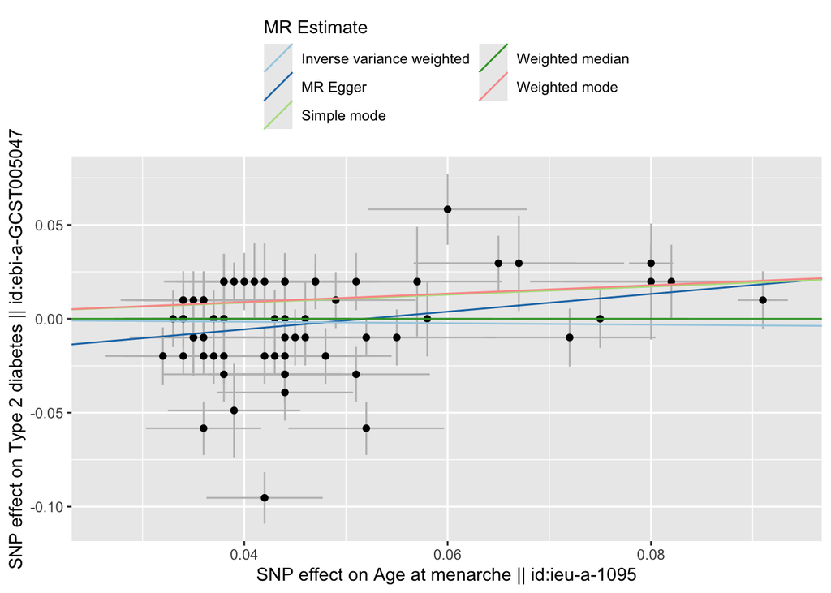

```r
#scatter plots of MR estimates
p1_res_aam_T2D <- mr_scatter_plot(res_aam_T2D, harmonized_data_aam_T2D)
p1_res_aam_T2D[[1]]
```

```r
#calculating heterogeneity
mr_heterogeneity(harmonized_data_aam_T2D)
```

```
  id.exposure       id.outcome                                outcome
1  ieu-a-1095 ebi-a-GCST005047 Type 2 diabetes || id:ebi-a-GCST005047
2  ieu-a-1095 ebi-a-GCST005047 Type 2 diabetes || id:ebi-a-GCST005047
                          exposure                    method        Q Q_df
1 Age at menarche || id:ieu-a-1095                  MR Egger 170.2504   64
2 Age at menarche || id:ieu-a-1095 Inverse variance weighted 184.9365   65
        Q_pval
1 1.379450e-11
2 1.913436e-13
```

```r
#calculating pleiotropy
mr_pleiotropy_test(harmonized_data_aam_T2D)
```

```
  id.exposure       id.outcome                                outcome
1  ieu-a-1095 ebi-a-GCST005047 Type 2 diabetes || id:ebi-a-GCST005047
                          exposure egger_intercept         se       pval
1 Age at menarche || id:ieu-a-1095     -0.02448412 0.01042043 0.02188916
```

```r
#single snp analysis
res_single_aam_T2D <- mr_singlesnp(harmonized_data_aam_T2D)
head(res_single_aam_T2D)
```

```
                          exposure                                outcome
1 Age at menarche || id:ieu-a-1095 Type 2 diabetes || id:ebi-a-GCST005047
2 Age at menarche || id:ieu-a-1095 Type 2 diabetes || id:ebi-a-GCST005047
3 Age at menarche || id:ieu-a-1095 Type 2 diabetes || id:ebi-a-GCST005047
4 Age at menarche || id:ieu-a-1095 Type 2 diabetes || id:ebi-a-GCST005047
5 Age at menarche || id:ieu-a-1095 Type 2 diabetes || id:ebi-a-GCST005047
6 Age at menarche || id:ieu-a-1095 Type 2 diabetes || id:ebi-a-GCST005047
  id.exposure       id.outcome samplesize        SNP          b        se
1  ieu-a-1095 ebi-a-GCST005047      12171 rs10144321 -0.4714905 0.3521333
2  ieu-a-1095 ebi-a-GCST005047      12171 rs10483727 -0.5352054 0.3997189
3  ieu-a-1095 ebi-a-GCST005047      12171  rs1079866 -0.1381990 0.2136694
4  ieu-a-1095 ebi-a-GCST005047      12171 rs10840031  0.0000000 0.3968684
5  ieu-a-1095 ebi-a-GCST005047      12171 rs10938397 -0.7778632 0.3854737
6  ieu-a-1095 ebi-a-GCST005047      12171 rs11022756 -0.4125542 0.3081167
          p
1 0.1805855
2 0.1805855
3 0.5177686
4 1.0000000
5 0.0435974
6 0.1805855
```

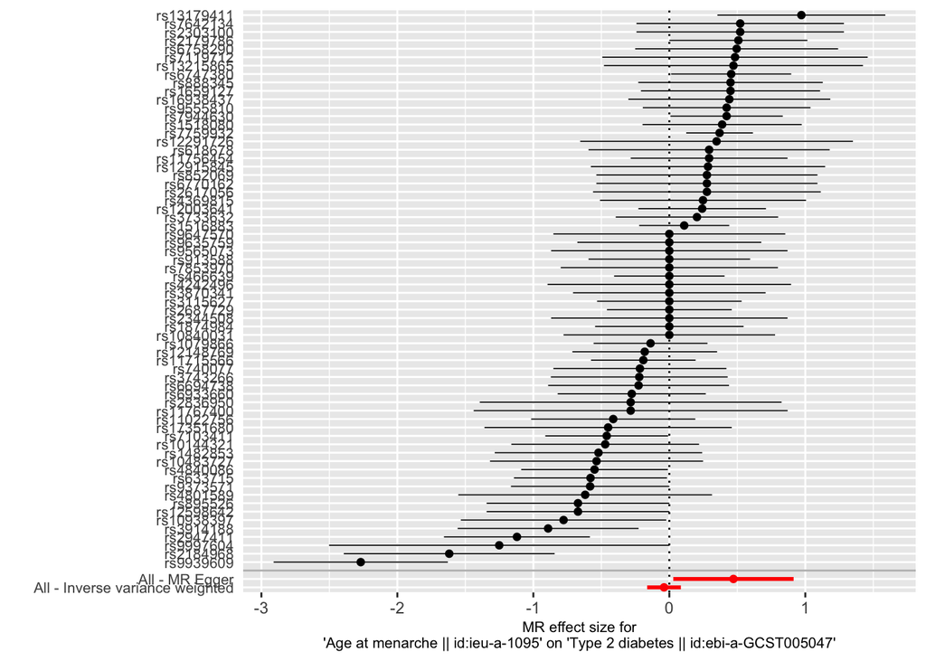

```r
#single snp results forest plot
p2_res_single_aam_T2D <- mr_forest_plot(res_single_aam_T2D)
p2_res_single_aam_T2D[[1]]
```

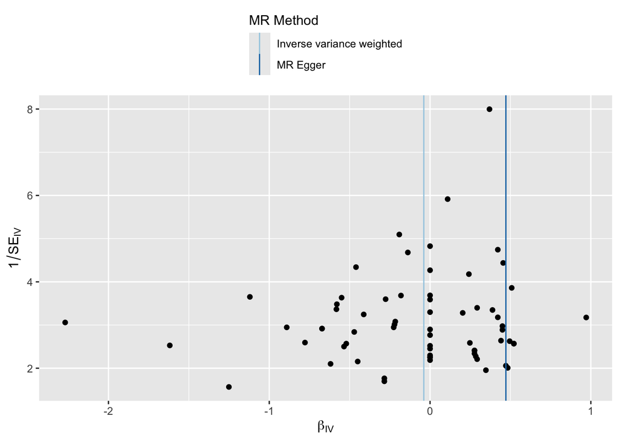

```r
#single snp results funnel plot
p4_res_single_aam_T2D <- mr_funnel_plot(res_single_aam_T2D)
p4_res_single_aam_T2D[[1]]
```

```r
#running loo
res_loo_aam_T2D <- mr_leaveoneout(harmonized_data_aam_T2D)
head(res_loo_aam_T2D)
```

```
                          exposure                                outcome
1 Age at menarche || id:ieu-a-1095 Type 2 diabetes || id:ebi-a-GCST005047
2 Age at menarche || id:ieu-a-1095 Type 2 diabetes || id:ebi-a-GCST005047
3 Age at menarche || id:ieu-a-1095 Type 2 diabetes || id:ebi-a-GCST005047
4 Age at menarche || id:ieu-a-1095 Type 2 diabetes || id:ebi-a-GCST005047
5 Age at menarche || id:ieu-a-1095 Type 2 diabetes || id:ebi-a-GCST005047
6 Age at menarche || id:ieu-a-1095 Type 2 diabetes || id:ebi-a-GCST005047
  id.exposure       id.outcome samplesize        SNP           b         se
1  ieu-a-1095 ebi-a-GCST005047      12171 rs10144321 -0.03405453 0.06378037
2  ieu-a-1095 ebi-a-GCST005047      12171 rs10483727 -0.03460836 0.06369375
3  ieu-a-1095 ebi-a-GCST005047      12171  rs1079866 -0.03585955 0.06464468
4  ieu-a-1095 ebi-a-GCST005047      12171 rs10840031 -0.03935612 0.06396557
5  ieu-a-1095 ebi-a-GCST005047      12171 rs10938397 -0.03196049 0.06333965
6  ieu-a-1095 ebi-a-GCST005047      12171 rs11022756 -0.03340051 0.06389831
          p
1 0.5933870
2 0.5868849
3 0.5790877
4 0.5383762
5 0.6138476
6 0.6011737
```

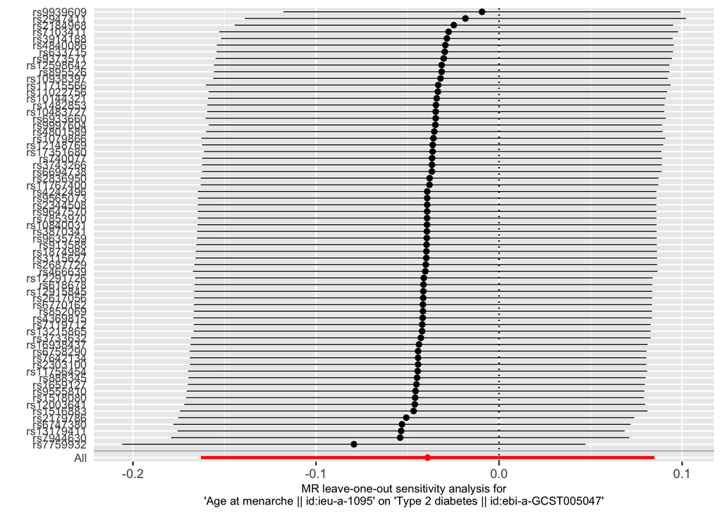

```r
#ploting loo reukts
res_loo_aam_T2D <- mr_leaveoneout_plot(res_loo_aam_T2D)
res_loo_aam_T2D[[1]]
```

```r
#steiger directionality test
out_aam_T2D <- directionality_test(harmonized_data_aam_T2D)
```

```
r.exposure and/or r.outcome not present.
```

```
Calculating approximate SNP-exposure and/or SNP-outcome correlations, assuming all are quantitative traits. Please pre-calculate r.exposure and/or r.outcome using get_r_from_lor() for any binary traits
```

```r
out_aam_T2D
```

```
  id.exposure       id.outcome                         exposure
1  ieu-a-1095 ebi-a-GCST005047 Age at menarche || id:ieu-a-1095
                                 outcome snp_r2.exposure snp_r2.outcome
1 Type 2 diabetes || id:ebi-a-GCST005047      0.02548295     0.01417032
  correct_causal_direction steiger_pval
1                     TRUE 9.771126e-06
```

### 4.1.2 Results for Forward MR (AAM → T2D)

[output not shown]

**Sensitivity analyses**

- Heterogeneity -> Strong heterogeneity was observed, indicating inconsistent SNP effects and suggesting possible pleiotropic effects.
- MR-Egger pleiotropy test -> the egger intercept was significant too, indicating directional pleiotropy is present, violating MR assumption of no pleiotropy.
- Steiger directionality test -> p = 9.77 × 10⁻⁶, confirming the correct causal direction is AAM to T2D, and that reverse causation is unlikely.
- Single SNP analysis( and the forest plot) -> Almost all the SNPs were non-significant, showing no strong outliers dominating the results.
  - Funnel plot: The SNPs show asymmetrical distribution. The MR Egger and IVW do not overlap indicating directional horizontal pleiotropy.
- Leave-one-out analysis -> All p-values remained insignificant, suggesting no SNP is driving the observed effect.
  - LOO plot -> Each dot represents the IVW estimate after removing one SNP at a time. All the estimates are close to 0 with the confidence intervals crossing 0, indicating no SNP shifts/drives the effect.

**Conclusion:** age at menarche does not causally influence T2D risk.

## 4.2 **Forward Multivariable MR (MVMR)**

Direction: AAM + BMI → T2D  
Exposures: Age at Menarche, Body Mass Index  
Outcome: Type 2 Diabetes  
Research Question: Does age at menarche affect T2D independent of BMI? and how does BMI affect T2D independent of AAM.

```r
###################################################
# Multivariable MR: AAM + BMI -> T2D
##################################################
# Instruments for AAM + BMI
exp_mv <- mv_extract_exposures(
  id_exposure = c("ieu-a-1095", "ieu-a-2"),
  clump_r2 = 0.001,
  clump_kb = 10000,
  pop = "EUR"
)
```

```
Please look at vignettes for options on running this locally if you need to run many instances of this command.
```

```
Clumping 1, 145 variants, using EUR population reference
```

```
Removing 24 of 145 variants due to LD with other variants or absence from LD reference panel
```

```
Extracting data for 121 SNP(s) from 2 GWAS(s)
```

```
Querying id chunk 1 of 1
```

```
Querying variant chunk 1 of 4
```

```
Querying variant chunk 2 of 4
```

```
Querying variant chunk 3 of 4
```

```
Querying variant chunk 4 of 4
```

```
Harmonising Age at menarche || id:ieu-a-1095 (ieu-a-1095) and Body mass index || id:ieu-a-2 (ieu-a-2)
```

```
Removing the following SNPs for being palindromic with intermediate allele frequencies:
rs1518080, rs1558902, rs1874984, rs4242496, rs4801589, rs9373571
```

```r
# Outcome: T2D
out_T2D <- extract_outcome_data(
  snps     = exp_mv$SNP,
  outcomes = "ebi-a-GCST005047"
)
```

```
Extracting data for 115 SNP(s) from 1 GWAS(s)
```

```
Querying id chunk 1 of 1
```

```
Querying variant chunk 1 of 2
```

```
Querying variant chunk 2 of 2
```

```
Finding proxies for 1 SNPs in outcome ebi-a-GCST005047
```

```
Extracting data for 1 SNP(s) from 1 GWAS(s)
```

```
Querying id chunk 1 of 1
```

```
Querying variant chunk 1 of 1
```

```r
# Harmonise
mvdat <- mv_harmonise_data(exp_mv, out_T2D)
```

```
Harmonising Age at menarche || id:ieu-a-1095 (ieu-a-1095) and Type 2 diabetes || id:ebi-a-GCST005047 (ebi-a-GCST005047)
```

```
Removing the following SNPs for being palindromic with intermediate allele frequencies:
rs1079866, rs14810, rs17001654, rs2617056, rs2836950, rs3914188, rs9304665, rs9555810, rs9579083, rs9914578
```

```r
# Multivariable MR
res_mvmr <- mv_multiple(mvdat)
res_mvmr
```

```
$result
  id.exposure                         exposure       id.outcome
1  ieu-a-1095 Age at menarche || id:ieu-a-1095 ebi-a-GCST005047
2     ieu-a-2    Body mass index || id:ieu-a-2 ebi-a-GCST005047
                                 outcome nsnp         b        se       pval
1 Type 2 diabetes || id:ebi-a-GCST005047   49 0.1014863 0.1084571 0.34941378
2 Type 2 diabetes || id:ebi-a-GCST005047   59 0.5860446 0.1858535 0.00161457
```

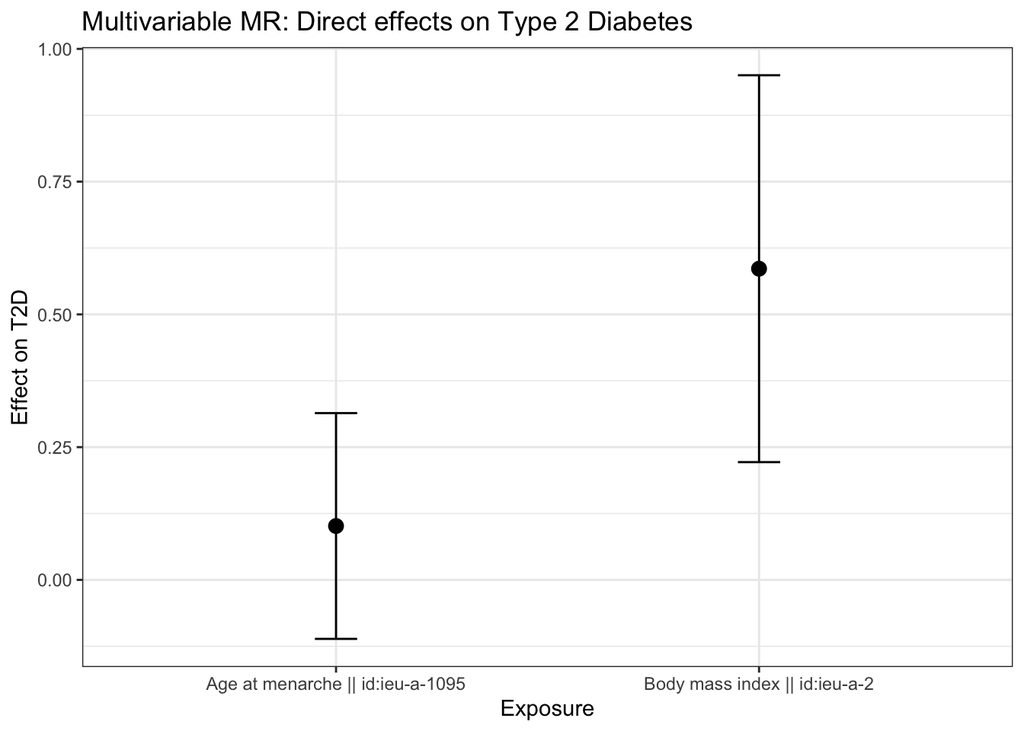

```r
# Main MVMR plot
ggplot(res_mvmr$result, aes(x = exposure, y = b)) +
  geom_point(size = 3) +
  geom_errorbar(
    aes(ymin = b - 1.96 * se, ymax = b + 1.96 * se),
    width = 0.1
  ) +
  theme_bw() +
  labs(
    title = "Multivariable MR: Direct effects on Type 2 Diabetes",
    x = "Exposure",
    y = "Effect on T2D"
  )
```

### 4.2.1 **Results for Forward Multivariable MR (**AAM + BMI→ T2D)

| Exposure | β | SE | p-value |
| --- | --- | --- | --- |
| AAM | 0.1014 | 0.1084 | 0.3494 |
| BMI | 0.5860 | 0.1858 | **0.0016** |

Looking at the MVMR results, age at menarche had insignificant p-values (0.34941378) while BMI had significant p-values (0.00161457). After adjusting for BMI, age at menarche has no direct causal effects on T2D, confirming our forward MR conclusion. However, BMI has strong direct causal effect on type 2 diabetes.

## 4.3 **Reverse MR**

Direction: T2D → AAM  
Exposure: Type 2 Diabetes  
Outcome: Age at Menarche  
Research Question: Does T2D causally influence age at menarche?

```r
###################################################
#Reverse MR: T2D -> AAM
##################################################

#Instruments for T2D (exposure)
exp_T2D <- extract_instruments("ebi-a-GCST005047") #t2d

#ld clumping
exp_T2D_clumped <- clump_data(exp_T2D, clump_r2 = 0.001, clump_kb =10000, pop = "EUR")
```

```
Please look at vignettes for options on running this locally if you need to run many instances of this command.
```

```
Clumping ebi-a-GCST005047, 34 variants, using EUR population reference
```

```r
exp_T2D_clumped$F_statistic <- (exp_T2D_clumped$beta.exposure^2) /
                               (exp_T2D_clumped$se.exposure^2)
summary(exp_T2D_clumped$F_statistic)
```

```
   Min. 1st Qu.  Median    Mean 3rd Qu.    Max.
  23.00   41.10   49.40   81.31   71.09  546.36
```

```r
#Outcome = aam
out_aam <- extract_outcome_data(
  snps     = exp_T2D_clumped$SNP,
  outcomes = "ieu-a-1095"
)
```

```
Extracting data for 34 SNP(s) from 1 GWAS(s)
```

```
Querying id chunk 1 of 1
```

```
Querying variant chunk 1 of 1
```

```r
#Harmonise
harmonise_data_T2D_aam <- harmonise_data(exp_T2D_clumped, out_aam, action = 1)
```

```
Harmonising Type 2 diabetes || id:ebi-a-GCST005047 (ebi-a-GCST005047) and Age at menarche || id:ieu-a-1095 (ieu-a-1095)
```

```r
#Reverse MR
res_T2D_aam <- mr(harmonise_data_T2D_aam)
```

```
Analysing 'ebi-a-GCST005047' on 'ieu-a-1095'
```

```r
res_T2D_aam
```

```
       id.exposure id.outcome                          outcome
1 ebi-a-GCST005047 ieu-a-1095 Age at menarche || id:ieu-a-1095
2 ebi-a-GCST005047 ieu-a-1095 Age at menarche || id:ieu-a-1095
3 ebi-a-GCST005047 ieu-a-1095 Age at menarche || id:ieu-a-1095
4 ebi-a-GCST005047 ieu-a-1095 Age at menarche || id:ieu-a-1095
5 ebi-a-GCST005047 ieu-a-1095 Age at menarche || id:ieu-a-1095
                                exposure                    method nsnp
1 Type 2 diabetes || id:ebi-a-GCST005047                  MR Egger   34
2 Type 2 diabetes || id:ebi-a-GCST005047           Weighted median   34
3 Type 2 diabetes || id:ebi-a-GCST005047 Inverse variance weighted   34
4 Type 2 diabetes || id:ebi-a-GCST005047               Simple mode   34
5 Type 2 diabetes || id:ebi-a-GCST005047             Weighted mode   34
             b         se      pval
1  0.083987705 0.04672760 0.0817170
2  0.009466472 0.01698853 0.5773722
3 -0.011680382 0.01871171 0.5324775
4 -0.021300886 0.03782269 0.5771209
5  0.025028326 0.02005179 0.2207474
```

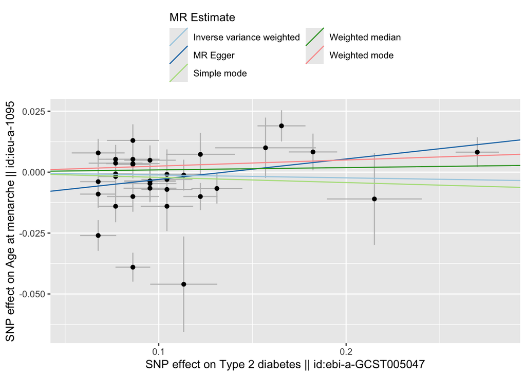

```r
# Scatter plot for MR estimatess
p1_res_T2D_aam <- mr_scatter_plot(res_T2D_aam, harmonise_data_T2D_aam)
p1_res_T2D_aam[[1]]
```

```r
#calculating heterogeneity
mr_heterogeneity(harmonise_data_T2D_aam)
```

```
       id.exposure id.outcome                          outcome
1 ebi-a-GCST005047 ieu-a-1095 Age at menarche || id:ieu-a-1095
2 ebi-a-GCST005047 ieu-a-1095 Age at menarche || id:ieu-a-1095
                                exposure                    method         Q
1 Type 2 diabetes || id:ebi-a-GCST005047                  MR Egger  92.64797
2 Type 2 diabetes || id:ebi-a-GCST005047 Inverse variance weighted 106.81604
  Q_df       Q_pval
1   32 8.245362e-08
2   33 1.029073e-09
```

```r
#calculating pleiotropy
mr_pleiotropy_test(harmonise_data_T2D_aam)
```

```
       id.exposure id.outcome                          outcome
1 ebi-a-GCST005047 ieu-a-1095 Age at menarche || id:ieu-a-1095
                                exposure egger_intercept          se       pval
1 Type 2 diabetes || id:ebi-a-GCST005047     -0.01137421 0.005141724 0.03421572
```

```r
#Single-SNP MR
res_single_T2D_aam <- mr_singlesnp(harmonise_data_T2D_aam)
head(res_single_T2D_aam)
```

```
                                exposure                          outcome
1 Type 2 diabetes || id:ebi-a-GCST005047 Age at menarche || id:ieu-a-1095
2 Type 2 diabetes || id:ebi-a-GCST005047 Age at menarche || id:ieu-a-1095
3 Type 2 diabetes || id:ebi-a-GCST005047 Age at menarche || id:ieu-a-1095
4 Type 2 diabetes || id:ebi-a-GCST005047 Age at menarche || id:ieu-a-1095
5 Type 2 diabetes || id:ebi-a-GCST005047 Age at menarche || id:ieu-a-1095
6 Type 2 diabetes || id:ebi-a-GCST005047 Age at menarche || id:ieu-a-1095
       id.exposure id.outcome samplesize        SNP           b         se
1 ebi-a-GCST005047 ieu-a-1095     182416 rs10099941 -0.05764234 0.08350232
2 ebi-a-GCST005047 ieu-a-1095     182416 rs10258074  0.03713258 0.06710089
3 ebi-a-GCST005047 ieu-a-1095     182416 rs10830961 -0.11603930 0.07260660
4 ebi-a-GCST005047 ieu-a-1095     182416 rs10842993  0.06150083 0.08323894
5 ebi-a-GCST005047 ieu-a-1095     182416 rs11257655 -0.03777140 0.07617506
6 ebi-a-GCST005047 ieu-a-1095     182416 rs11708067 -0.04931267 0.07484802
          p
1 0.4900004
2 0.5800003
3 0.1100002
4 0.4600000
5 0.6200002
6 0.5100003
```

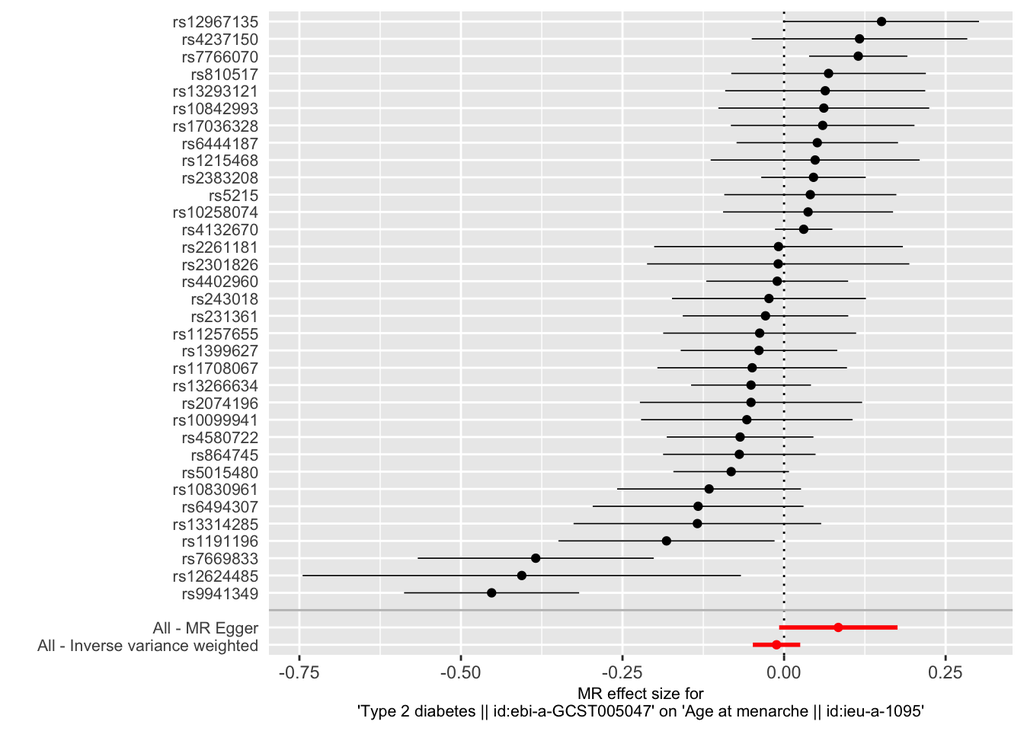

```r
#Forest plot for Single-SNP MR
p2_res_single_T2D_aam <- mr_forest_plot(res_single_T2D_aam)
p2_res_single_T2D_aam[[1]]
```

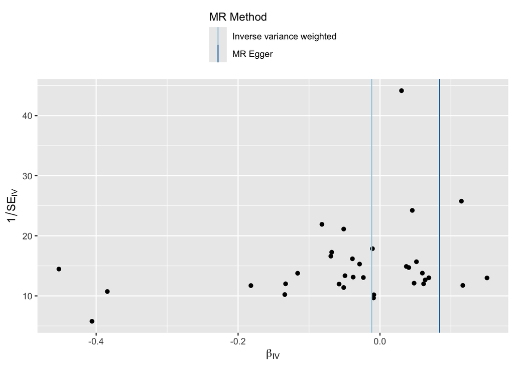

```r
#Funnel plot for Single-SNP MR
p4_res_single_T2D_aam <- mr_funnel_plot(res_single_T2D_aam)
p4_res_single_T2D_aam[[1]]
```

```r
#Leave-one-out
res_loo_T2D_aam <- mr_leaveoneout(harmonise_data_T2D_aam)
head(res_loo_T2D_aam)
```

```
                                exposure                          outcome
1 Type 2 diabetes || id:ebi-a-GCST005047 Age at menarche || id:ieu-a-1095
2 Type 2 diabetes || id:ebi-a-GCST005047 Age at menarche || id:ieu-a-1095
3 Type 2 diabetes || id:ebi-a-GCST005047 Age at menarche || id:ieu-a-1095
4 Type 2 diabetes || id:ebi-a-GCST005047 Age at menarche || id:ieu-a-1095
5 Type 2 diabetes || id:ebi-a-GCST005047 Age at menarche || id:ieu-a-1095
6 Type 2 diabetes || id:ebi-a-GCST005047 Age at menarche || id:ieu-a-1095
       id.exposure id.outcome samplesize        SNP            b         se
1 ebi-a-GCST005047 ieu-a-1095     182416 rs10099941 -0.010956119 0.01912335
2 ebi-a-GCST005047 ieu-a-1095     182416 rs10258074 -0.012881937 0.01918540
3 ebi-a-GCST005047 ieu-a-1095     182416 rs10830961 -0.009494204 0.01900933
4 ebi-a-GCST005047 ieu-a-1095     182416 rs10842993 -0.012840987 0.01908139
5 ebi-a-GCST005047 ieu-a-1095     182416 rs11257655 -0.011184770 0.01917072
6 ebi-a-GCST005047 ieu-a-1095     182416 rs11708067 -0.010939461 0.01916481
          p
1 0.5666999
2 0.5019371
3 0.6174626
4 0.5009736
5 0.5596040
6 0.5681286
```

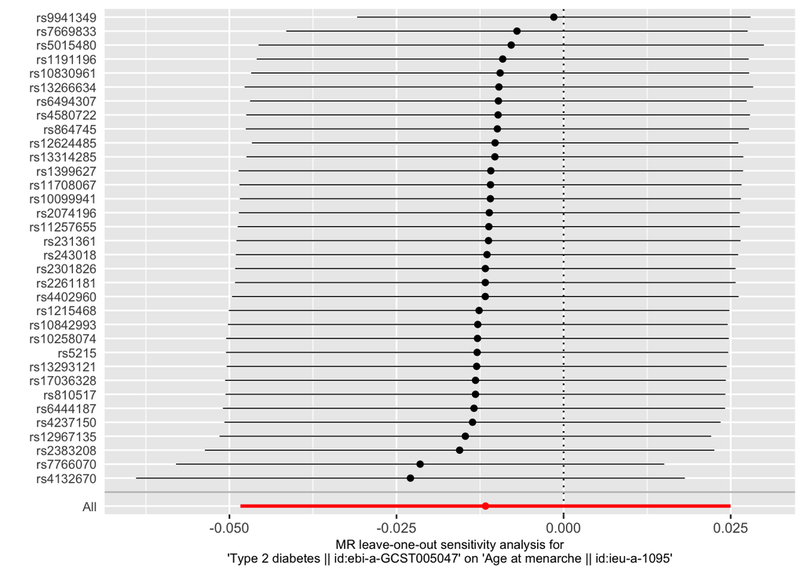

```r
#Leave-one-out plot
p_loo_T2D_aam <- mr_leaveoneout_plot(res_loo_T2D_aam)
p_loo_T2D_aam[[1]]
```

```r
#Steiger directionality test
out_T2D_aam <- directionality_test(harmonise_data_T2D_aam)
```

```
r.exposure and/or r.outcome not present.
```

```
Calculating approximate SNP-exposure and/or SNP-outcome correlations, assuming all are quantitative traits. Please pre-calculate r.exposure and/or r.outcome using get_r_from_lor() for any binary traits
```

```r
out_T2D_aam
```

```
       id.exposure id.outcome                               exposure
1 ebi-a-GCST005047 ieu-a-1095 Type 2 diabetes || id:ebi-a-GCST005047
                           outcome snp_r2.exposure snp_r2.outcome
1 Age at menarche || id:ieu-a-1095       0.1541034    0.000592452
  correct_causal_direction steiger_pval
1                     TRUE            0
```

### 4.3.1 Results for Reverse MR (T2D → AAM)

[output not shown]

MR scatter plot: The SNP points are mostly distributed close to 0 and the MR estimates points show a similar pattern except for the MR-Egger line, which shows a noticeable positive slope. Since most of the MR estimates show no causal effect, the MR-Egger is likely influenced by pleiotropy.

**Sensitivity analyses**

- Heterogeneity -> Strong heterogeneity was observed( MR Egger and IVW Qp-values 8.245362e-08 and 1.029073e-09 respectively), indicating inconsistent SNP effects and suggesting possible pleiotropic effects.
- MR-Egger pleiotropy test -> The egger intercept was significant, indicating directional pleiotropy is present, violating MR assumption of no pleiotropy, meaning some T2D affects AAM through pathways other than T2D.
- Steiger directionality test -> p = 0 which is significant, causal direction is correct T2D to AAM.
- Single SNP analysis (and the forest plots)-> A few SNPs are significant but the majority are non significant (p-values >0.05 and CI crossing 0). The effect sizes go in both positive and negative directions and with no consistent patterns. Even though MR-Egger is slightly positive and IVW estimate, they both overlap 0, thus not significant, indicating no causal effect of type 2 diabetes on age at menarche.
  - Funnel plot: The SNPs show asymmetrical distribution, with most SNPs below 0 indicating directional horizontal pleiotropy.
- Leave-one-out analysis -> All p-values remained insignificant, suggesting no SNP is driving the observed effect.
  - LOO plot -> Each dot represents the IVW estimate after removing one SNP at a time. All the estimates are less than 0 and near -0.01 with the confidence intervals crossing 0, indicating no SNP shifts/drives the effect.

Conclusion: This MR analysis provides no evidence that the T2D has a direct causal effect on age at menarche.

## 4.4 **Reverse Multivariable MR (MVMR)**

Direction: T2D + BMI → AAM  
Exposures: Type 2 Diabetes, Body Mass Index  
Outcome: Age at Menarche  
Research Question: Does T2D influence age at menarche independent of BMI? and does BMI causally influence T2D independent of AAM.

```r
###################################################
# Reverse MVMR: T2D + BMI -> AAM
##################################################
#exposure t2d and bmi
exp_mv_rev <- mv_extract_exposures(
  id_exposure = c(
    "ebi-a-GCST005047",   # t2d
    "ieu-a-2"            # BMI
  ),
  clump_r2 = 0.001,
  clump_kb = 10000,
  pop = "EUR"
)
```

```
Please look at vignettes for options on running this locally if you need to run many instances of this command.
```

```
Clumping 1, 112 variants, using EUR population reference
```

```
Removing 11 of 112 variants due to LD with other variants or absence from LD reference panel
```

```
Extracting data for 101 SNP(s) from 2 GWAS(s)
```

```
Querying id chunk 1 of 1
```

```
Querying variant chunk 1 of 4
```

```
Querying variant chunk 2 of 4
```

```
Querying variant chunk 3 of 4
```

```
Querying variant chunk 4 of 4
```

```
Finding proxies for 1 SNPs in outcome ebi-a-GCST005047
```

```
Extracting data for 1 SNP(s) from 1 GWAS(s)
```

```
Querying id chunk 1 of 1
```

```
Querying variant chunk 1 of 1
```

```
Harmonising Type 2 diabetes || id:ebi-a-GCST005047 (ebi-a-GCST005047) and Body mass index || id:ieu-a-2 (ieu-a-2)
```

```
Removing the following SNPs for being palindromic with intermediate allele frequencies:
rs10258074, rs14810, rs1558902, rs17001654, rs4237150, rs6494307, rs9304665, rs9579083, rs9914578
```

```r
#Outcome = aam
out_aam_rev <- extract_outcome_data(
  snps     = exp_mv_rev$SNP,
  outcomes = "ieu-a-1095"
)
```

```
Extracting data for 91 SNP(s) from 1 GWAS(s)
```

```
Querying id chunk 1 of 1
```

```
Querying variant chunk 1 of 2
```

```
Querying variant chunk 2 of 2
```

```r
#Harmonise
mvdat_rev_T2D_aam <- mv_harmonise_data(exp_mv_rev, out_aam_rev)
```

```
Harmonising Type 2 diabetes || id:ebi-a-GCST005047 (ebi-a-GCST005047) and Age at menarche || id:ieu-a-1095 (ieu-a-1095)
```

```r
#Reverse multivariable MR
res_mvmr_rev_T2D_aam <- mv_multiple(mvdat_rev_T2D_aam)
res_mvmr_rev_T2D_aam$result
```

```
       id.exposure                               exposure id.outcome
1 ebi-a-GCST005047 Type 2 diabetes || id:ebi-a-GCST005047 ieu-a-1095
2          ieu-a-2          Body mass index || id:ieu-a-2 ieu-a-1095
                           outcome nsnp           b         se         pval
1 Age at menarche || id:ieu-a-1095   26 -0.02802139 0.01820380 1.237274e-01
2 Age at menarche || id:ieu-a-1095   67 -0.53030869 0.05138305 5.681115e-25
```

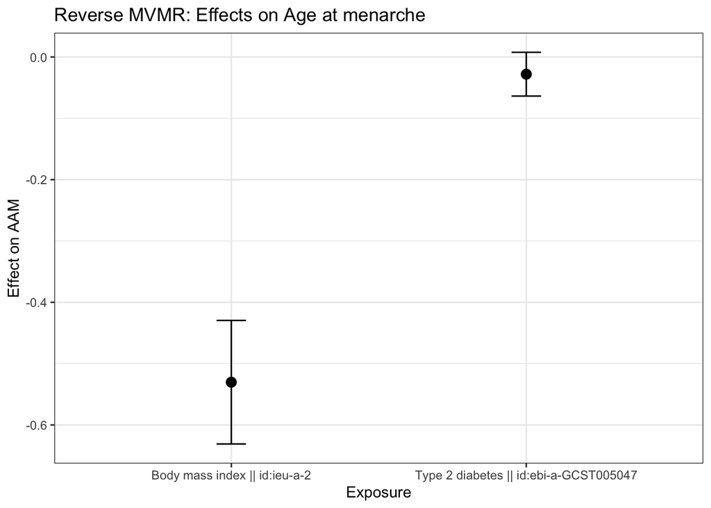

```r
#Plot reverse MVMR
ggplot(res_mvmr_rev_T2D_aam$result, aes(x = exposure, y = b)) +
  geom_point(size = 3) +
  geom_errorbar(
    aes(ymin = b - 1.96 * se, ymax = b + 1.96 * se),
    width = 0.1
  ) +
  theme_bw() +
  labs(
    title = "Reverse MVMR: Effects on Age at menarche",
    x = "Exposure",
    y = "Effect on AAM"
  )
```

### 4.4.1 **Results for Reverse Multivariable MR (T2D + BMI** → AAM)

| Exposure | β | SE | p-value |
| --- | --- | --- | --- |
| T2D | -0.028 | 0.018 | 1.237274e-01 |
| BMI | -0.530 | 0.051 | 5.681115e-25 |

The p-values for T2D was insignificant, indicating that T2D has no direct causal effect on age at menarche even after adjusting for BMI. However, BMI was significant with a negative beta, suggesting that higher BMI leads to earlier age at menarche independent of T2D.

This suggests that BMI rather than T2D is a primary causal determinant for early puberty.

## 4.5 Age at Menarche and Lipid levels

Lipids used LDL, HDL, Triglycerides (TG) and Total Cholesterol (TC)

## 4.6 **Forward MR**

Direction: AAM → LDL, AAM → HDL, AAM → TG, AAM →TC  
Exposure: Age at Menarche  
Outcome: LDL, HDL, TG, TC  
Research Question: Does age at menarche causally influence each lipid levels?

```r
###################################################
# Forward MR: AAM -> Lipids
##################################################


###we alredy have clumped_exp_AAM from the previous MR

#TG -> ebi-a-GCST002216
#TC -> ebi-a-GCST002221
#LDL -> ebi-a-GCST002222
#HDL -> ebi-a-GCST002223
lipids <- c(
  "ebi-a-GCST002222",  # LDL
  "ebi-a-GCST002223",  # HDL
  "ebi-a-GCST002216",  # Triglycerides
  "ebi-a-GCST002221"   # Total Cholesterol
)

###Loop AAM -> Lipids MR
mr_results_aam_to_lipids <- list()
harmonised_results <- list()

for(lipid in lipids){

  outcome_lipids <- extract_outcome_data(
    snps = clumped_exp_aam$SNP,
    outcomes = lipid
  )

  harmonise_data_aam_to_lipids <- harmonise_data(
    exposure_dat = clumped_exp_aam,
    outcome_dat = outcome_lipids
  )

  harmonised_results[[lipid]] <- harmonise_data_aam_to_lipids

  if(nrow(harmonise_data_aam_to_lipids) > 3){
    res_aam_to_lipids <- mr(harmonise_data_aam_to_lipids)
  } else {
    res_aam_to_lipids <- NA
  }

  mr_results_aam_to_lipids[[lipid]] <- res_aam_to_lipids
}
```

```
Extracting data for 66 SNP(s) from 1 GWAS(s)
```

```
Querying id chunk 1 of 1
```

```
Querying variant chunk 1 of 2
```

```
Querying variant chunk 2 of 2
```

```
Finding proxies for 1 SNPs in outcome ebi-a-GCST002222
```

```
Extracting data for 1 SNP(s) from 1 GWAS(s)
```

```
Querying id chunk 1 of 1
```

```
Querying variant chunk 1 of 1
```

```
Harmonising Age at menarche || id:ieu-a-1095 (ieu-a-1095) and LDL cholesterol || id:ebi-a-GCST002222 (ebi-a-GCST002222)
```

```
Removing the following SNPs for being palindromic with intermediate allele frequencies:
rs1079866, rs11756454, rs1518080, rs17351680, rs1874984, rs2617056, rs2836950, rs3914188, rs4242496, rs4801589, rs9373571, rs9555810, rs9939609
```

```
Analysing 'ieu-a-1095' on 'ebi-a-GCST002222'
```

```
Extracting data for 66 SNP(s) from 1 GWAS(s)
```

```
Querying id chunk 1 of 1
```

```
Querying variant chunk 1 of 2
```

```
Querying variant chunk 2 of 2
```

```
Harmonising Age at menarche || id:ieu-a-1095 (ieu-a-1095) and HDL cholesterol || id:ebi-a-GCST002223 (ebi-a-GCST002223)
```

```
Removing the following SNPs for being palindromic with intermediate allele frequencies:
rs1079866, rs11756454, rs1518080, rs17351680, rs1874984, rs2617056, rs2836950, rs3914188, rs4242496, rs4801589, rs9373571, rs9555810, rs9939609
```

```
Analysing 'ieu-a-1095' on 'ebi-a-GCST002223'
```

```
Extracting data for 66 SNP(s) from 1 GWAS(s)
```

```
Querying id chunk 1 of 1
```

```
Querying variant chunk 1 of 2
```

```
Querying variant chunk 2 of 2
```

```
Harmonising Age at menarche || id:ieu-a-1095 (ieu-a-1095) and Triglycerides || id:ebi-a-GCST002216 (ebi-a-GCST002216)
```

```
Removing the following SNPs for being palindromic with intermediate allele frequencies:
rs1079866, rs11756454, rs1518080, rs17351680, rs1874984, rs2617056, rs2836950, rs3914188, rs4242496, rs4801589, rs9373571, rs9555810, rs9939609
```

```
Analysing 'ieu-a-1095' on 'ebi-a-GCST002216'
```

```
Extracting data for 66 SNP(s) from 1 GWAS(s)
```

```
Querying id chunk 1 of 1
```

```
Querying variant chunk 1 of 2
```

```
Querying variant chunk 2 of 2
```

```
Finding proxies for 1 SNPs in outcome ebi-a-GCST002221
```

```
Extracting data for 1 SNP(s) from 1 GWAS(s)
```

```
Querying id chunk 1 of 1
```

```
Querying variant chunk 1 of 1
```

```
Harmonising Age at menarche || id:ieu-a-1095 (ieu-a-1095) and Cholesterol, total || id:ebi-a-GCST002221 (ebi-a-GCST002221)
```

```
Removing the following SNPs for being palindromic with intermediate allele frequencies:
rs1079866, rs11756454, rs1518080, rs17351680, rs1874984, rs2617056, rs2836950, rs3914188, rs4242496, rs4801589, rs9373571, rs9555810, rs9939609
```

```
Analysing 'ieu-a-1095' on 'ebi-a-GCST002221'
```

```r
mr_results_aam_to_lipids
```

```
$`ebi-a-GCST002222`
  id.exposure       id.outcome                                outcome
1  ieu-a-1095 ebi-a-GCST002222 LDL cholesterol || id:ebi-a-GCST002222
2  ieu-a-1095 ebi-a-GCST002222 LDL cholesterol || id:ebi-a-GCST002222
3  ieu-a-1095 ebi-a-GCST002222 LDL cholesterol || id:ebi-a-GCST002222
4  ieu-a-1095 ebi-a-GCST002222 LDL cholesterol || id:ebi-a-GCST002222
5  ieu-a-1095 ebi-a-GCST002222 LDL cholesterol || id:ebi-a-GCST002222
                          exposure                    method nsnp            b
1 Age at menarche || id:ieu-a-1095                  MR Egger   53 -0.027240702
2 Age at menarche || id:ieu-a-1095           Weighted median   53  0.008413812
3 Age at menarche || id:ieu-a-1095 Inverse variance weighted   53  0.006126733
4 Age at menarche || id:ieu-a-1095               Simple mode   53 -0.009294822
5 Age at menarche || id:ieu-a-1095             Weighted mode   53 -0.002438460
          se      pval
1 0.08054616 0.7366009
```

[output cut: 64 more lines]

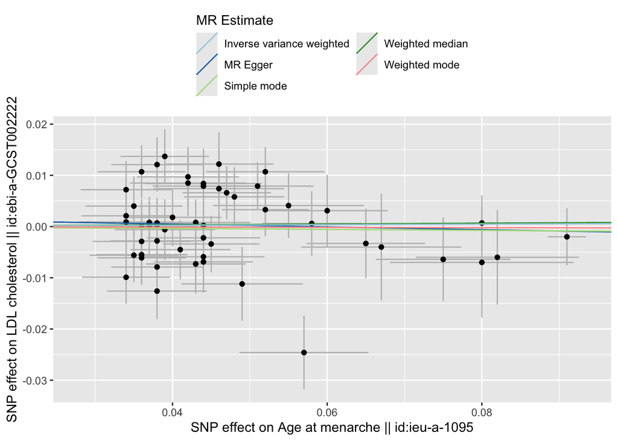

```r
#############################
###Plot results for AAM_to_LDL
data_aam_to_ldl <- harmonised_results[["ebi-a-GCST002222"]]
res_aam_to_ldl <- mr_results_aam_to_lipids[["ebi-a-GCST002222"]]

#scatter plot

p1_res_aam_to_ldl <- mr_scatter_plot(res_aam_to_ldl, data_aam_to_ldl)
p1_res_aam_to_ldl[[1]]
```

```r
# Heterogeneity & pleiotropy
mr_heterogeneity(data_aam_to_ldl)
```

```
  id.exposure       id.outcome                                outcome
1  ieu-a-1095 ebi-a-GCST002222 LDL cholesterol || id:ebi-a-GCST002222
2  ieu-a-1095 ebi-a-GCST002222 LDL cholesterol || id:ebi-a-GCST002222
                          exposure                    method        Q Q_df
1 Age at menarche || id:ieu-a-1095                  MR Egger 81.95895   51
2 Age at menarche || id:ieu-a-1095 Inverse variance weighted 82.25479   52
       Q_pval
1 0.003858749
2 0.004739495
```

```r
mr_pleiotropy_test(data_aam_to_ldl)
```

```
  id.exposure       id.outcome                                outcome
1  ieu-a-1095 ebi-a-GCST002222 LDL cholesterol || id:ebi-a-GCST002222
                          exposure egger_intercept          se      pval
1 Age at menarche || id:ieu-a-1095     0.001585285 0.003694829 0.6696903
```

```r
# Single-SNP MR
res_single_aam_to_ldl <- mr_singlesnp(data_aam_to_ldl)
head(res_single_aam_to_ldl)
```

```
                          exposure                                outcome
1 Age at menarche || id:ieu-a-1095 LDL cholesterol || id:ebi-a-GCST002222
2 Age at menarche || id:ieu-a-1095 LDL cholesterol || id:ebi-a-GCST002222
3 Age at menarche || id:ieu-a-1095 LDL cholesterol || id:ebi-a-GCST002222
4 Age at menarche || id:ieu-a-1095 LDL cholesterol || id:ebi-a-GCST002222
5 Age at menarche || id:ieu-a-1095 LDL cholesterol || id:ebi-a-GCST002222
6 Age at menarche || id:ieu-a-1095 LDL cholesterol || id:ebi-a-GCST002222
  id.exposure       id.outcome samplesize        SNP           b        se
1  ieu-a-1095 ebi-a-GCST002222      94595 rs10144321  0.23095238 0.1404762
2  ieu-a-1095 ebi-a-GCST002222      94595 rs10483727  0.02162162 0.1027027
3  ieu-a-1095 ebi-a-GCST002222      94595 rs10840031  0.01842105 0.1052632
4  ieu-a-1095 ebi-a-GCST002222      94595 rs10938397 -0.20789474 0.1000000
5  ieu-a-1095 ebi-a-GCST002222      94595 rs11022756  0.12083333 0.1208333
6  ieu-a-1095 ebi-a-GCST002222      94595 rs11715566  0.06346154 0.1000000
           p
1 0.10016220
2 0.83325691
3 0.86107963
4 0.03762219
5 0.31731051
6 0.52567929
```

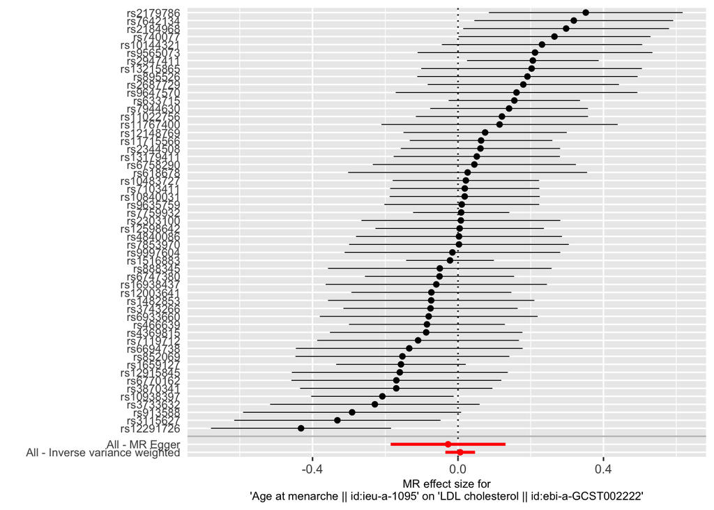

```r
p2_res_single_aam_to_ldl <- mr_forest_plot(res_single_aam_to_ldl)
p2_res_single_aam_to_ldl[[1]]
```

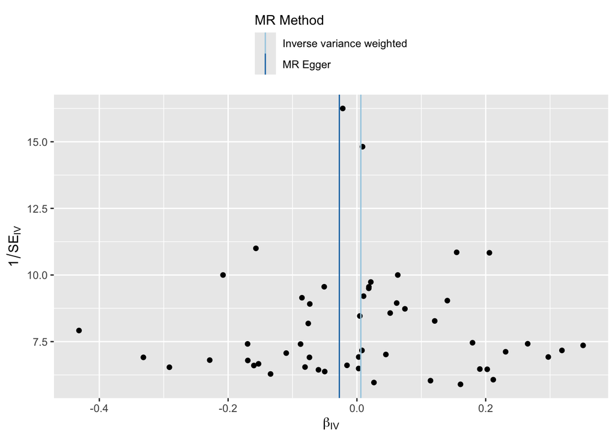

```r
p4_res_single_aam_to_ldl <- mr_funnel_plot(res_single_aam_to_ldl)
p4_res_single_aam_to_ldl[[1]]
```

```r
# Leave-one-out
res_loo_aam_to_ldl <- mr_leaveoneout(data_aam_to_ldl)
head(res_loo_aam_to_ldl)
```

```
                          exposure                                outcome
1 Age at menarche || id:ieu-a-1095 LDL cholesterol || id:ebi-a-GCST002222
2 Age at menarche || id:ieu-a-1095 LDL cholesterol || id:ebi-a-GCST002222
3 Age at menarche || id:ieu-a-1095 LDL cholesterol || id:ebi-a-GCST002222
4 Age at menarche || id:ieu-a-1095 LDL cholesterol || id:ebi-a-GCST002222
5 Age at menarche || id:ieu-a-1095 LDL cholesterol || id:ebi-a-GCST002222
6 Age at menarche || id:ieu-a-1095 LDL cholesterol || id:ebi-a-GCST002222
  id.exposure       id.outcome samplesize        SNP           b         se
1  ieu-a-1095 ebi-a-GCST002222      94595 rs10144321 0.002966598 0.02081423
2  ieu-a-1095 ebi-a-GCST002222      94595 rs10483727 0.005714219 0.02127849
3  ieu-a-1095 ebi-a-GCST002222      94595 rs10840031 0.005815554 0.02126611
4  ieu-a-1095 ebi-a-GCST002222      94595 rs10938397 0.012145471 0.02067841
5  ieu-a-1095 ebi-a-GCST002222      94595 rs11022756 0.003936797 0.02108462
6  ieu-a-1095 ebi-a-GCST002222      94595 rs11715566 0.004514357 0.02125326
          p
1 0.8866635
2 0.7882804
3 0.7844952
4 0.5569684
5 0.8518847
6 0.8317889
```

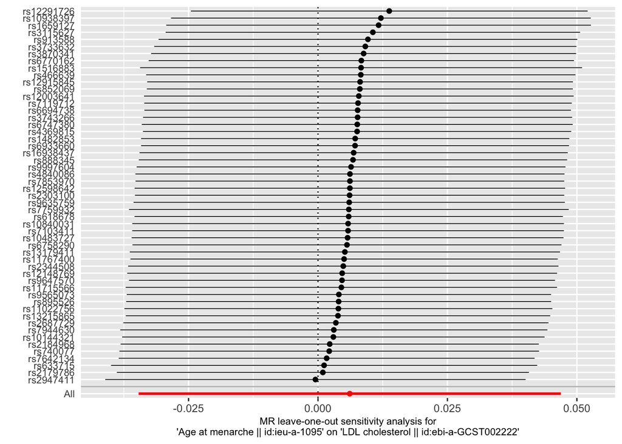

```r
p_loo_aam_to_ldl <- mr_leaveoneout_plot(res_loo_aam_to_ldl)
p_loo_aam_to_ldl[[1]]
```

```r
# Steiger directionality
out_aam_to_ldl <- directionality_test(data_aam_to_ldl)
```

```
r.exposure and/or r.outcome not present.
```

```
Calculating approximate SNP-exposure and/or SNP-outcome correlations, assuming all are quantitative traits. Please pre-calculate r.exposure and/or r.outcome using get_r_from_lor() for any binary traits
```

```r
out_aam_to_ldl
```

```
  id.exposure       id.outcome                         exposure
1  ieu-a-1095 ebi-a-GCST002222 Age at menarche || id:ieu-a-1095
                                 outcome snp_r2.exposure snp_r2.outcome
1 LDL cholesterol || id:ebi-a-GCST002222      0.02548295    0.001084392
  correct_causal_direction  steiger_pval
1                     TRUE 3.503484e-224
```

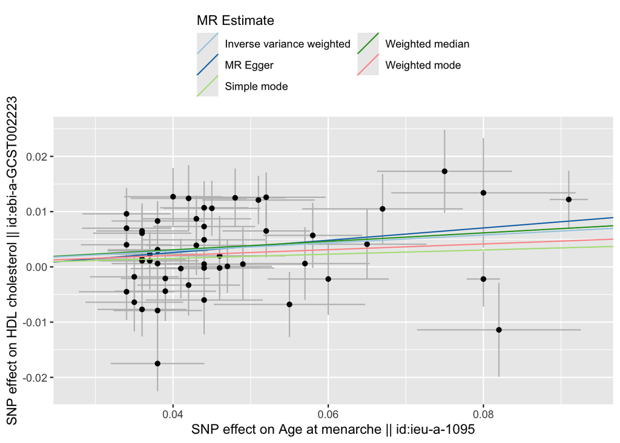

```r
#############################
###Plot results for AAM_to_HDL

data_aam_to_hdl <- harmonised_results[["ebi-a-GCST002223"]]
res_aam_to_hdl <- mr_results_aam_to_lipids[["ebi-a-GCST002223"]]

#scatter plot

p1_res_aam_to_hdl <- mr_scatter_plot(res_aam_to_hdl, data_aam_to_hdl)
p1_res_aam_to_hdl[[1]]
```

```r
# Heterogeneity & pleiotropy
mr_heterogeneity(data_aam_to_hdl)
```

```
  id.exposure       id.outcome                                outcome
1  ieu-a-1095 ebi-a-GCST002223 HDL cholesterol || id:ebi-a-GCST002223
2  ieu-a-1095 ebi-a-GCST002223 HDL cholesterol || id:ebi-a-GCST002223
                          exposure                    method        Q Q_df
1 Age at menarche || id:ieu-a-1095                  MR Egger 87.65555   51
2 Age at menarche || id:ieu-a-1095 Inverse variance weighted 88.14995   52
       Q_pval
1 0.001075513
2 0.001294944
```

```r
mr_pleiotropy_test(data_aam_to_hdl)
```

```
  id.exposure       id.outcome                                outcome
1  ieu-a-1095 ebi-a-GCST002223 HDL cholesterol || id:ebi-a-GCST002223
                          exposure egger_intercept          se      pval
1 Age at menarche || id:ieu-a-1095    -0.001874735 0.003495469 0.5940602
```

```r
# Single-SNP MR
res_single_aam_to_hdl <- mr_singlesnp(data_aam_to_hdl)
head(res_single_aam_to_hdl)
```

```
                          exposure                                outcome
1 Age at menarche || id:ieu-a-1095 HDL cholesterol || id:ebi-a-GCST002223
2 Age at menarche || id:ieu-a-1095 HDL cholesterol || id:ebi-a-GCST002223
3 Age at menarche || id:ieu-a-1095 HDL cholesterol || id:ebi-a-GCST002223
4 Age at menarche || id:ieu-a-1095 HDL cholesterol || id:ebi-a-GCST002223
5 Age at menarche || id:ieu-a-1095 HDL cholesterol || id:ebi-a-GCST002223
6 Age at menarche || id:ieu-a-1095 HDL cholesterol || id:ebi-a-GCST002223
  id.exposure       id.outcome samplesize        SNP           b         se
1  ieu-a-1095 ebi-a-GCST002223      94595 rs10144321 -0.07857143 0.13095238
2  ieu-a-1095 ebi-a-GCST002223      94595 rs10483727  0.06216216 0.09459459
3  ieu-a-1095 ebi-a-GCST002223      94595 rs10840031  0.08157895 0.09736842
4  ieu-a-1095 ebi-a-GCST002223      94595 rs10938397  0.21842105 0.09473684
5  ieu-a-1095 ebi-a-GCST002223      94595 rs11022756  0.26041667 0.11041667
6  ieu-a-1095 ebi-a-GCST002223      94595 rs11715566  0.12500000 0.09230769
           p
1 0.54850624
2 0.51108906
3 0.40212178
4 0.02113548
5 0.01834943
6 0.17568321
```

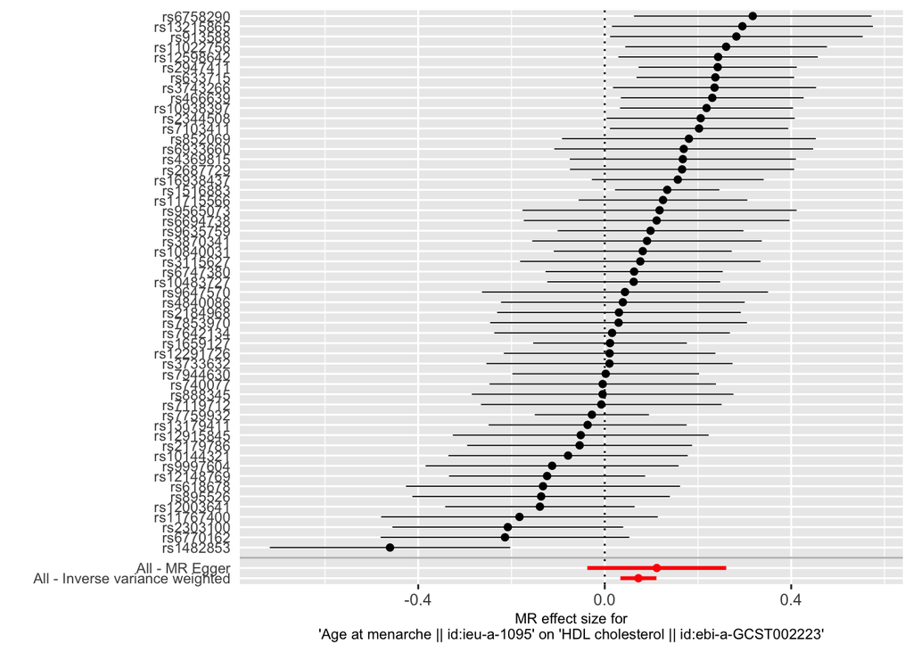

```r
p2_res_single_aam_to_hdl <- mr_forest_plot(res_single_aam_to_hdl)
p2_res_single_aam_to_hdl[[1]]
```

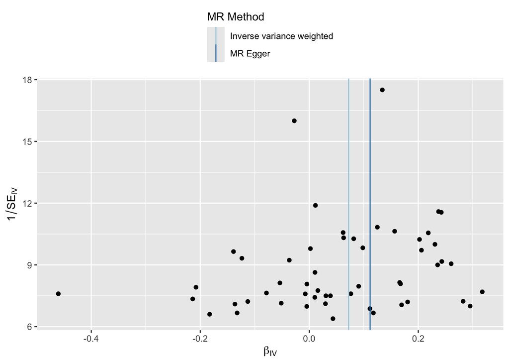

```r
p4_res_single_aam_to_hdl <- mr_funnel_plot(res_single_aam_to_hdl)
p4_res_single_aam_to_hdl[[1]]
```

```r
# Leave-one-out
res_loo_aam_to_hdl <- mr_leaveoneout(data_aam_to_hdl)
head(res_loo_aam_to_hdl)
```

```
                          exposure                                outcome
1 Age at menarche || id:ieu-a-1095 HDL cholesterol || id:ebi-a-GCST002223
2 Age at menarche || id:ieu-a-1095 HDL cholesterol || id:ebi-a-GCST002223
3 Age at menarche || id:ieu-a-1095 HDL cholesterol || id:ebi-a-GCST002223
4 Age at menarche || id:ieu-a-1095 HDL cholesterol || id:ebi-a-GCST002223
5 Age at menarche || id:ieu-a-1095 HDL cholesterol || id:ebi-a-GCST002223
6 Age at menarche || id:ieu-a-1095 HDL cholesterol || id:ebi-a-GCST002223
  id.exposure       id.outcome samplesize        SNP          b         se
1  ieu-a-1095 ebi-a-GCST002223      94595 rs10144321 0.07435240 0.01990659
2  ieu-a-1095 ebi-a-GCST002223      94595 rs10483727 0.07257121 0.02018489
3  ieu-a-1095 ebi-a-GCST002223      94595 rs10840031 0.07207371 0.02017026
4  ieu-a-1095 ebi-a-GCST002223      94595 rs10938397 0.06846616 0.01990396
5  ieu-a-1095 ebi-a-GCST002223      94595 rs11022756 0.06869179 0.01977545
6  ieu-a-1095 ebi-a-GCST002223      94595 rs11715566 0.07084406 0.02016118
             p
1 0.0001876665
2 0.0003239885
3 0.0003525554
4 0.0005820888
5 0.0005135465
6 0.0004416047
```

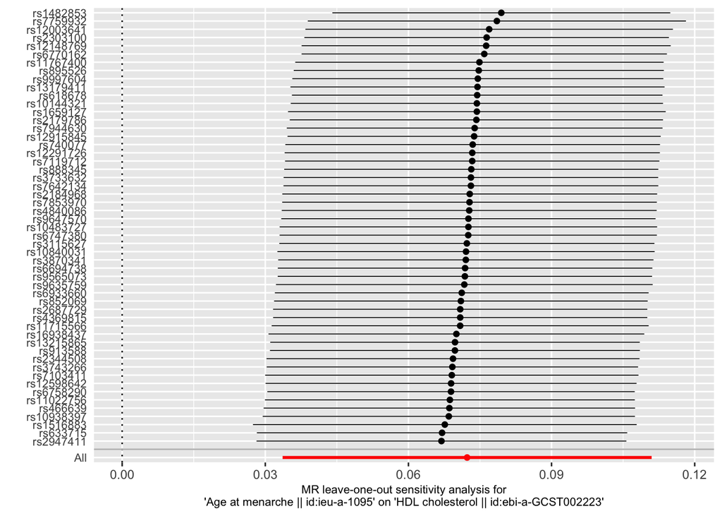

```r
p_loo_aam_to_hdl <- mr_leaveoneout_plot(res_loo_aam_to_hdl)
p_loo_aam_to_hdl[[1]]
```

```r
# Steiger directionality
out_aam_to_hdl <- directionality_test(data_aam_to_hdl)
```

```
r.exposure and/or r.outcome not present.
Calculating approximate SNP-exposure and/or SNP-outcome correlations, assuming all are quantitative traits. Please pre-calculate r.exposure and/or r.outcome using get_r_from_lor() for any binary traits
```

```r
out_aam_to_hdl
```

```
  id.exposure       id.outcome                         exposure
1  ieu-a-1095 ebi-a-GCST002223 Age at menarche || id:ieu-a-1095
                                 outcome snp_r2.exposure snp_r2.outcome
1 HDL cholesterol || id:ebi-a-GCST002223      0.02548295    0.001443805
  correct_causal_direction steiger_pval
1                     TRUE 6.19622e-207
```

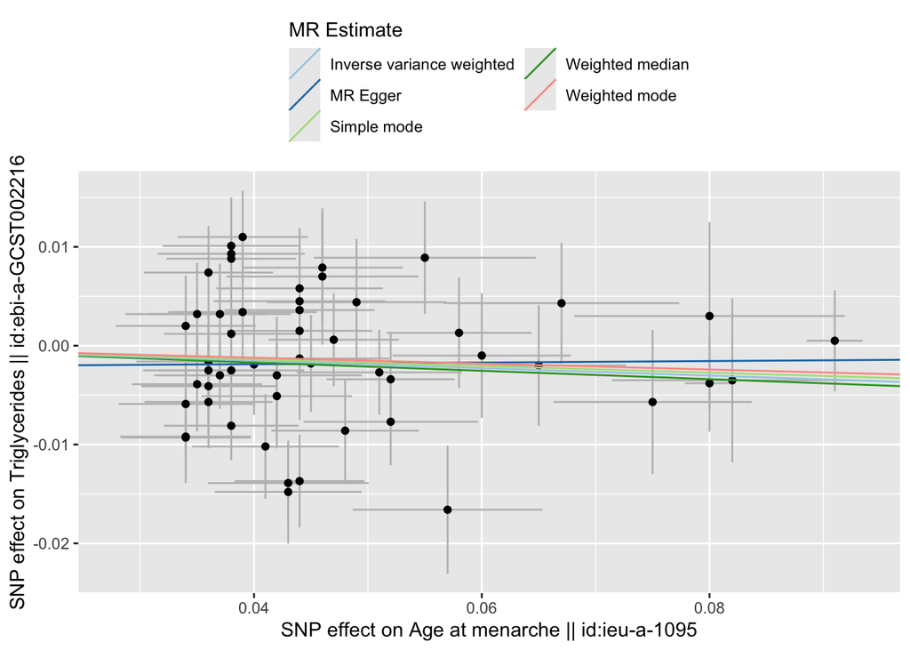

```r
#############################
###Plot results for AAM_to_TG

data_aam_to_tg <- harmonised_results[["ebi-a-GCST002216"]]
res_aam_to_tg <- mr_results_aam_to_lipids[["ebi-a-GCST002216"]]

#scatter plot

p1_res_aam_to_tg <- mr_scatter_plot(res_aam_to_tg, data_aam_to_tg)
p1_res_aam_to_tg[[1]]
```

```r
# Heterogeneity & pleiotropy
mr_heterogeneity(data_aam_to_tg)
```

```
  id.exposure       id.outcome                              outcome
1  ieu-a-1095 ebi-a-GCST002216 Triglycerides || id:ebi-a-GCST002216
2  ieu-a-1095 ebi-a-GCST002216 Triglycerides || id:ebi-a-GCST002216
                          exposure                    method        Q Q_df
1 Age at menarche || id:ieu-a-1095                  MR Egger 93.44222   51
2 Age at menarche || id:ieu-a-1095 Inverse variance weighted 94.13350   52
       Q_pval
1 0.000267592
2 0.000313809
```

```r
mr_pleiotropy_test(data_aam_to_tg)
```

```
  id.exposure       id.outcome                              outcome
1  ieu-a-1095 ebi-a-GCST002216 Triglycerides || id:ebi-a-GCST002216
                          exposure egger_intercept          se      pval
1 Age at menarche || id:ieu-a-1095    -0.002165198 0.003524994 0.5417862
```

```r
# Single-SNP MR
res_single_aam_to_tg <- mr_singlesnp(data_aam_to_tg)
head(res_single_aam_to_tg)
```

```
                          exposure                              outcome
1 Age at menarche || id:ieu-a-1095 Triglycerides || id:ebi-a-GCST002216
2 Age at menarche || id:ieu-a-1095 Triglycerides || id:ebi-a-GCST002216
3 Age at menarche || id:ieu-a-1095 Triglycerides || id:ebi-a-GCST002216
4 Age at menarche || id:ieu-a-1095 Triglycerides || id:ebi-a-GCST002216
5 Age at menarche || id:ieu-a-1095 Triglycerides || id:ebi-a-GCST002216
6 Age at menarche || id:ieu-a-1095 Triglycerides || id:ebi-a-GCST002216
  id.exposure       id.outcome samplesize        SNP           b         se
1  ieu-a-1095 ebi-a-GCST002216      94595 rs10144321 -0.12142857 0.12619048
2  ieu-a-1095 ebi-a-GCST002216      94595 rs10483727 -0.08108108 0.09189189
3  ieu-a-1095 ebi-a-GCST002216      94595 rs10840031 -0.06578947 0.09473684
4  ieu-a-1095 ebi-a-GCST002216      94595 rs10938397 -0.21315789 0.09210526
5  ieu-a-1095 ebi-a-GCST002216      94595 rs11022756 -0.17916667 0.10833333
6  ieu-a-1095 ebi-a-GCST002216      94595 rs11715566 -0.06538462 0.09038462
           p
1 0.33591693
2 0.37758598
3 0.48740353
4 0.02065205
5 0.09815878
6 0.46943156
```

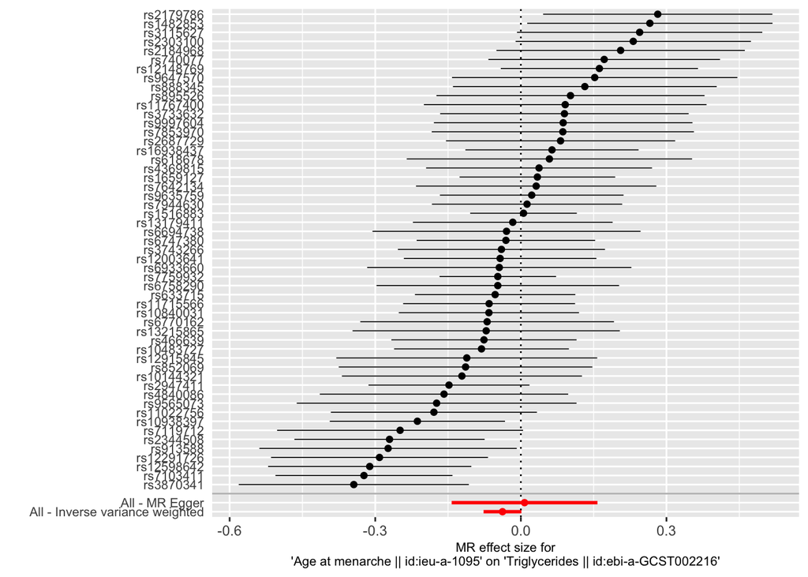

```r
p2_res_single_aam_to_tg <- mr_forest_plot(res_single_aam_to_tg)
p2_res_single_aam_to_tg[[1]]
```

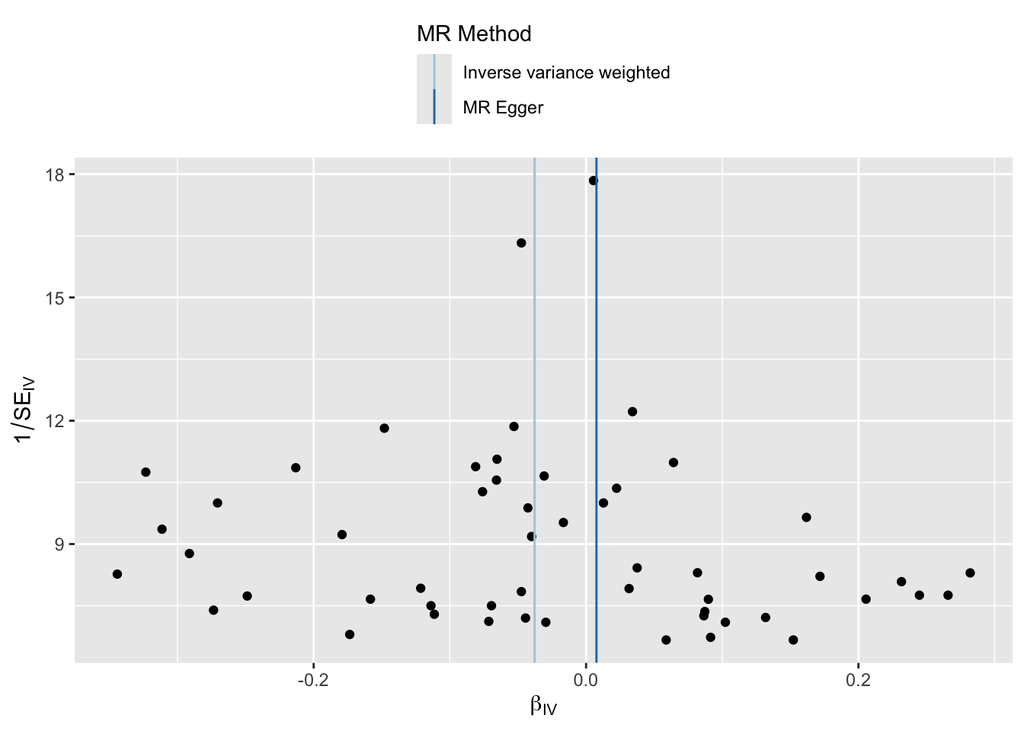

```r
p4_res_single_aam_to_tg <- mr_funnel_plot(res_single_aam_to_tg)
p4_res_single_aam_to_tg[[1]]
```

```r
# Leave-one-out
res_loo_aam_to_tg <- mr_leaveoneout(data_aam_to_tg)
head(res_loo_aam_to_tg)
```

```
                          exposure                              outcome
1 Age at menarche || id:ieu-a-1095 Triglycerides || id:ebi-a-GCST002216
2 Age at menarche || id:ieu-a-1095 Triglycerides || id:ebi-a-GCST002216
3 Age at menarche || id:ieu-a-1095 Triglycerides || id:ebi-a-GCST002216
4 Age at menarche || id:ieu-a-1095 Triglycerides || id:ebi-a-GCST002216
5 Age at menarche || id:ieu-a-1095 Triglycerides || id:ebi-a-GCST002216
6 Age at menarche || id:ieu-a-1095 Triglycerides || id:ebi-a-GCST002216
  id.exposure       id.outcome samplesize        SNP           b         se
1  ieu-a-1095 ebi-a-GCST002216      94595 rs10144321 -0.03663803 0.02016919
2  ieu-a-1095 ebi-a-GCST002216      94595 rs10483727 -0.03665182 0.02031813
3  ieu-a-1095 ebi-a-GCST002216      94595 rs10840031 -0.03710289 0.02031713
4  ieu-a-1095 ebi-a-GCST002216      94595 rs10938397 -0.03316708 0.01993546
5  ieu-a-1095 ebi-a-GCST002216      94595 rs11022756 -0.03512031 0.02007976
6  ieu-a-1095 ebi-a-GCST002216      94595 rs11715566 -0.03704328 0.02034149
           p
1 0.06928848
2 0.07124744
3 0.06782203
4 0.09616784
5 0.08028410
6 0.06859626
```

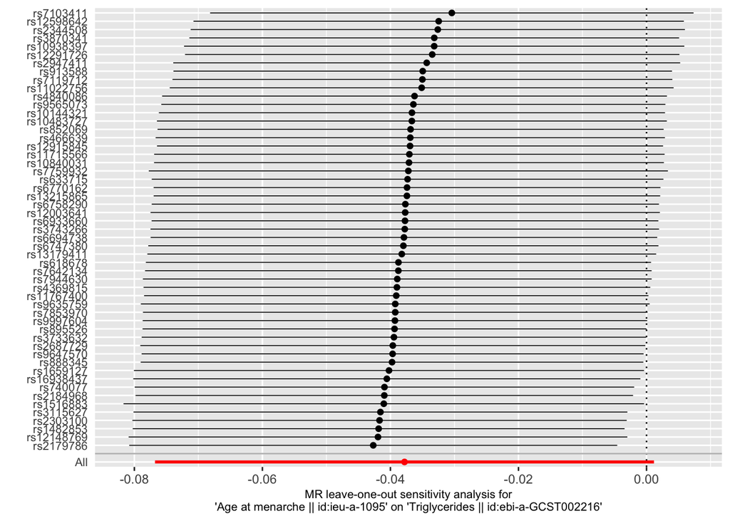

```r
p_loo_aam_to_tg <- mr_leaveoneout_plot(res_loo_aam_to_tg)
p_loo_aam_to_tg[[1]]
```

```r
# Steiger directionality
out_aam_to_tg <- directionality_test(data_aam_to_tg)
```

```
r.exposure and/or r.outcome not present.
Calculating approximate SNP-exposure and/or SNP-outcome correlations, assuming all are quantitative traits. Please pre-calculate r.exposure and/or r.outcome using get_r_from_lor() for any binary traits
```

```r
out_aam_to_tg
```

```
  id.exposure       id.outcome                         exposure
1  ieu-a-1095 ebi-a-GCST002216 Age at menarche || id:ieu-a-1095
                               outcome snp_r2.exposure snp_r2.outcome
1 Triglycerides || id:ebi-a-GCST002216      0.02548295    0.001328211
  correct_causal_direction  steiger_pval
1                     TRUE 3.802734e-212
```

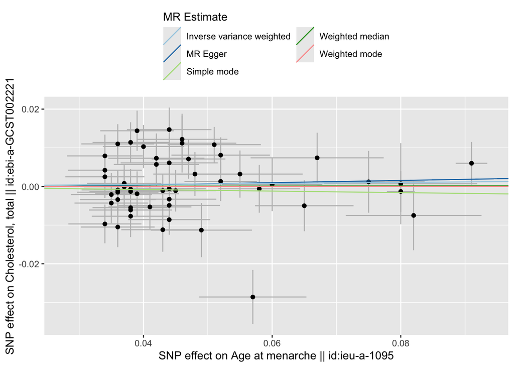

```r
#############################
###Plot results for AAM_to_TC

data_aam_to_tc <- harmonised_results[["ebi-a-GCST002221"]]
res_aam_to_tc <- mr_results_aam_to_lipids[["ebi-a-GCST002221"]]

#scatter plot
p1_res_aam_to_tc <- mr_scatter_plot(res_aam_to_tc, data_aam_to_tc)
p1_res_aam_to_tc[[1]]
```

```r
# Heterogeneity & pleiotropy
mr_heterogeneity(data_aam_to_tc)
```

```
  id.exposure       id.outcome                                   outcome
1  ieu-a-1095 ebi-a-GCST002221 Cholesterol, total || id:ebi-a-GCST002221
2  ieu-a-1095 ebi-a-GCST002221 Cholesterol, total || id:ebi-a-GCST002221
                          exposure                    method        Q Q_df
1 Age at menarche || id:ieu-a-1095                  MR Egger 99.17389   51
2 Age at menarche || id:ieu-a-1095 Inverse variance weighted 99.24734   52
        Q_pval
1 6.208624e-05
2 8.694777e-05
```

```r
mr_pleiotropy_test(data_aam_to_tc)
```

```
  id.exposure       id.outcome                                   outcome
1  ieu-a-1095 ebi-a-GCST002221 Cholesterol, total || id:ebi-a-GCST002221
                          exposure egger_intercept          se     pval
1 Age at menarche || id:ieu-a-1095   -0.0007638566 0.003930419 0.846678
```

```r
# Single-SNP MR
res_single_aam_to_tc <- mr_singlesnp(data_aam_to_tc)
head(res_single_aam_to_tc)
```

```
                          exposure                                   outcome
1 Age at menarche || id:ieu-a-1095 Cholesterol, total || id:ebi-a-GCST002221
2 Age at menarche || id:ieu-a-1095 Cholesterol, total || id:ebi-a-GCST002221
3 Age at menarche || id:ieu-a-1095 Cholesterol, total || id:ebi-a-GCST002221
4 Age at menarche || id:ieu-a-1095 Cholesterol, total || id:ebi-a-GCST002221
5 Age at menarche || id:ieu-a-1095 Cholesterol, total || id:ebi-a-GCST002221
6 Age at menarche || id:ieu-a-1095 Cholesterol, total || id:ebi-a-GCST002221
  id.exposure       id.outcome samplesize        SNP           b         se
1  ieu-a-1095 ebi-a-GCST002221      94595 rs10144321  0.13571429 0.13809524
2  ieu-a-1095 ebi-a-GCST002221      94595 rs10483727  0.02162162 0.10000000
3  ieu-a-1095 ebi-a-GCST002221      94595 rs10840031 -0.03421053 0.10000000
4  ieu-a-1095 ebi-a-GCST002221      94595 rs10938397 -0.14473684 0.09736842
5  ieu-a-1095 ebi-a-GCST002221      94595 rs11022756  0.06666667 0.11875000
6  ieu-a-1095 ebi-a-GCST002221      94595 rs11715566  0.02500000 0.09807692
          p
1 0.3257263
2 0.8288192
3 0.7322717
4 0.1371505
5 0.5745225
6 0.7987988
```

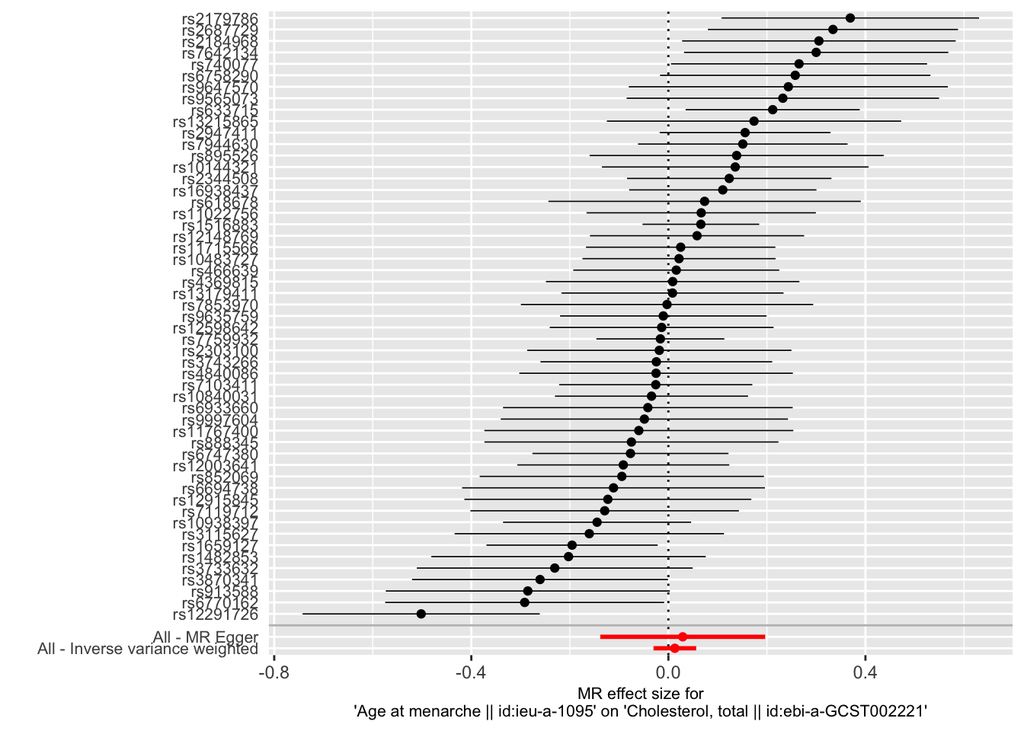

```r
p2_res_single_aam_to_tc <- mr_forest_plot(res_single_aam_to_tc)
p2_res_single_aam_to_tc[[1]]
```

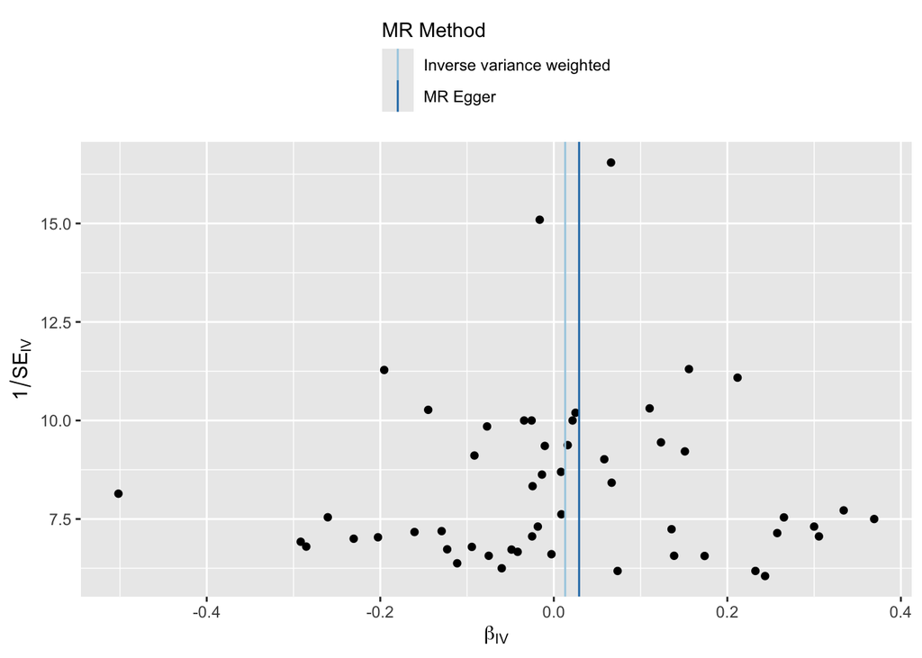

```r
p4_res_single_aam_to_tc <- mr_funnel_plot(res_single_aam_to_tc)
p4_res_single_aam_to_tc[[1]]
```

```r
# Leave-one-out
res_loo_aam_to_tc <- mr_leaveoneout(data_aam_to_tc)
head(res_loo_aam_to_tc)
```

```
                          exposure                                   outcome
1 Age at menarche || id:ieu-a-1095 Cholesterol, total || id:ebi-a-GCST002221
2 Age at menarche || id:ieu-a-1095 Cholesterol, total || id:ebi-a-GCST002221
3 Age at menarche || id:ieu-a-1095 Cholesterol, total || id:ebi-a-GCST002221
4 Age at menarche || id:ieu-a-1095 Cholesterol, total || id:ebi-a-GCST002221
5 Age at menarche || id:ieu-a-1095 Cholesterol, total || id:ebi-a-GCST002221
6 Age at menarche || id:ieu-a-1095 Cholesterol, total || id:ebi-a-GCST002221
  id.exposure       id.outcome samplesize        SNP          b         se
1  ieu-a-1095 ebi-a-GCST002221      94595 rs10144321 0.01144708 0.02238989
2  ieu-a-1095 ebi-a-GCST002221      94595 rs10483727 0.01289296 0.02261984
3  ieu-a-1095 ebi-a-GCST002221      94595 rs10840031 0.01436103 0.02259448
4  ieu-a-1095 ebi-a-GCST002221      94595 rs10938397 0.01750096 0.02232681
5  ieu-a-1095 ebi-a-GCST002221      94595 rs11022756 0.01212565 0.02251115
6  ieu-a-1095 ebi-a-GCST002221      94595 rs11715566 0.01279141 0.02263075
          p
1 0.6091683
2 0.5686883
3 0.5250377
4 0.4331258
5 0.5901278
6 0.5719224
```

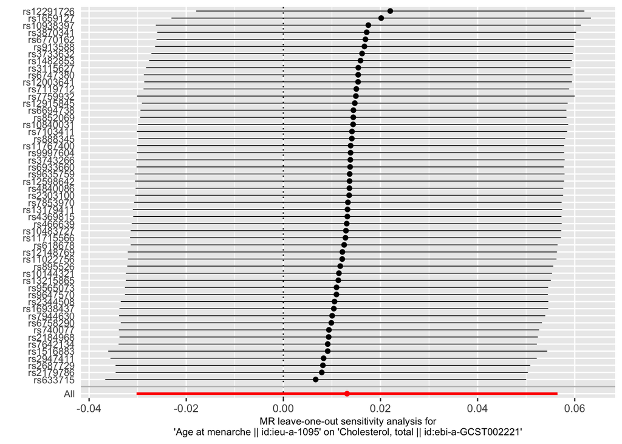

```r
p_loo_aam_to_tc <- mr_leaveoneout_plot(res_loo_aam_to_tc)
p_loo_aam_to_tc[[1]]
```

```r
# Steiger directionality
out_aam_to_tc <- directionality_test(data_aam_to_tc)
```

```
r.exposure and/or r.outcome not present.
Calculating approximate SNP-exposure and/or SNP-outcome correlations, assuming all are quantitative traits. Please pre-calculate r.exposure and/or r.outcome using get_r_from_lor() for any binary traits
```

```r
out_aam_to_tc
```

```
  id.exposure       id.outcome                         exposure
1  ieu-a-1095 ebi-a-GCST002221 Age at menarche || id:ieu-a-1095
                                    outcome snp_r2.exposure snp_r2.outcome
1 Cholesterol, total || id:ebi-a-GCST002221      0.02548295    0.001376164
  correct_causal_direction  steiger_pval
1                     TRUE 5.979091e-210
```